# How can we catch more bad guys ?

## What's happening the most in districts ?

Let's take two districts as examples and see what are the most common crimes in there :

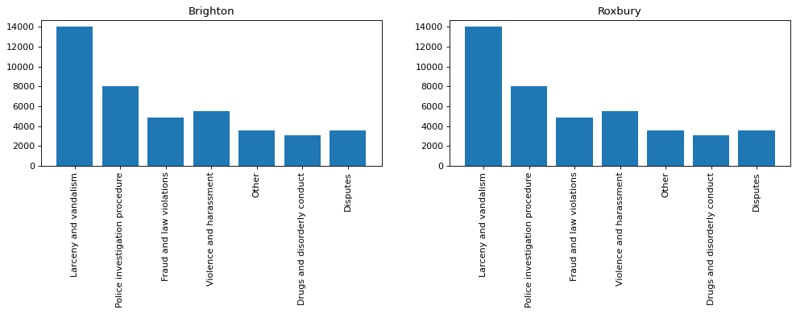

```python
figure(figsize=(15, 3), dpi=80)
plt.subplot(1, 2, 1)
plt.title('Brighton')
plt.bar(df_brighton['OFFENSE_CODE_GROUP'], df_brighton['count'])
plt.xticks(rotation = 90)
plt.subplot(1, 2, 2)
plt.title('Roxbury')
plt.bar(df_roxbury['OFFENSE_CODE_GROUP'], df_roxbury['count'])
plt.xticks(rotation = 90)
plt.show()
```

We have saw that Larceny and vandalism is the most current crimes in both district, it's almost the double of the second place : Police investigation procedure.

## What about the hours of the crimes ?

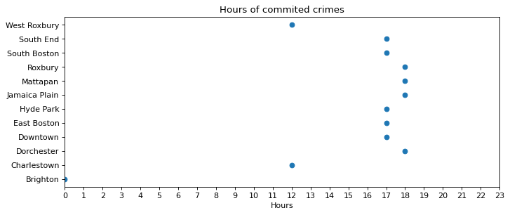

```python
figure(figsize=(10, 4), dpi=80)
plt.scatter(res['OCCURRED_ON_DATE'], res['NAME'])
plt.xticks(np.arange(0,24))
plt.xlabel("Hours")
plt.xlim(right = 23, left = 0)
plt.title('Hours of commited crimes')
plt.show()
```

As we can see, most of the crimes are commited between 5pm and 7pm

## Now, let's see how far are the commited crime from the police station depending on the district

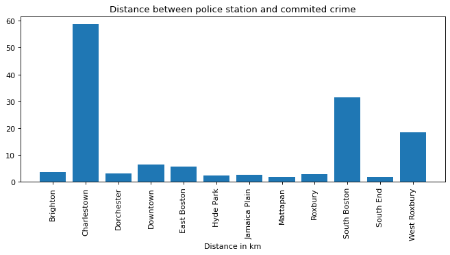

```python
figure(figsize=(10, 4), dpi=80)
plt.bar(result_distance['NAME'], result_distance['haversine_distance'])
plt.xticks(rotation=90)
plt.xlabel("Distance in km")
plt.title('Distance between police station and commited crime')
plt.show()
```

In conclusion :

- We should investigate on why there is so much larceny and vandalism, it's the most frequent case in 90% of the districts.
- We could deploy more police teams between 5pm and 7pm to prevent and anticipate the peak of commited crimes before night time.
- For certain district where the crimes are far from the police station, maybe we can relocate the station to be more effective on the duration between the crime and the intervention of the police.

Thank for your attention